# Utilisation du Markdown avec Pandoc

Baptiste PIERARD

21 avril 2020

# 1 INTRODUCTION

## 1.1 But, Responsabilités, Domaine d’application

### 1.1.1 Objectifs

Ce paragraphe donne la raison d’être du document. Il s’articule de la manière suivante :

- But du système dans une description rapide.
- But du Sous-Système dans une description rapide.
- But du document.

Cette description de quelques lignes apparaîtra dans tous les documents relatifs au sous-système. Il est conseillé de recopier mot pour mot cette description sur l’ensemble des documents.

### 1.1.2 Responsabilités

Ce paragraphe donne les responsabilités associées au document, notamment :

- le nom de l’auteur ou de l’équipe de rédaction,
- le nom du vérificateur,
- le nom de celui qui approuve le document.

Si ces informations sont déjà données dans le Plan Qualité du projet, il faut l’indiquer par la phrase suivante :

Les responsabilités associées à ce document sont définies dans le Plan Qualité du Projet.

### 1.1.3 Domaine d’application

Ce paragraphe précise à quel sous-ensemble du projet correspond ce document, et à quelle version du ou des composants. Par exemple s’il s’agit d’un logiciel :

## 1.2 Hypothèses

Ce paragraphe décrit les hypothèses utilisées pour la rédaction. Les parties en italiques dans ce modèle sont des guides de rédactions.

## 1.3 Documents applicables, de référence

Ces paragraphes donnent la liste des documents d’entrée de ce document.

### 1.3.1 Documents Médiane Système applicables

Doivent au moins apparaître

- le Manuel Qualité de Médiane Système,
- le Plan Qualité du projet puis,
- la Spécification si ce document est une Conception,
- et ainsi de suite…

Documents applicables.

[output not shown]

### 1.3.2 Documents externes applicables

Peuvent apparaître :

- le Cahier des charges si ce document est une Spécification,
- des spécifications client,
- et ainsi de suite…

Documents exernes applicables.

[output not shown]

### 1.3.3 Documents de référence

Un document de référence est un document utilisé pour la rédaction de cette spécification :

- guide de rédaction,
- manuel utilisateur d’un logiciel,
- règlements
- etc…

Les documents cités doivent être identifiés de la même manière que pour les documents applicables.

Identification des documents.

[output not shown]

## 1.4 Terminologie

Ce paragraphe permet au lecteur néophyte de se débrouiller dans la jungle des sigles et symboles du projet… Ne pas hésiter à renvoyer à un document donnant une définition exacte des sigles ou noms les plus importants.

| Terme ou symbole | Correspondance |
| --- | --- |
| **RTFM** | **R**ead **T**he **F**ile **M**anual Ayez l’obligeance de vous reporter au manuel utilisateur |
| **PDJ** | **P**etit **D**é**J**euner Repas le plus important de la journée |

# 2 CONTENU DU DOCUMENT…

Ce document présente l’architecture générale du logicel :

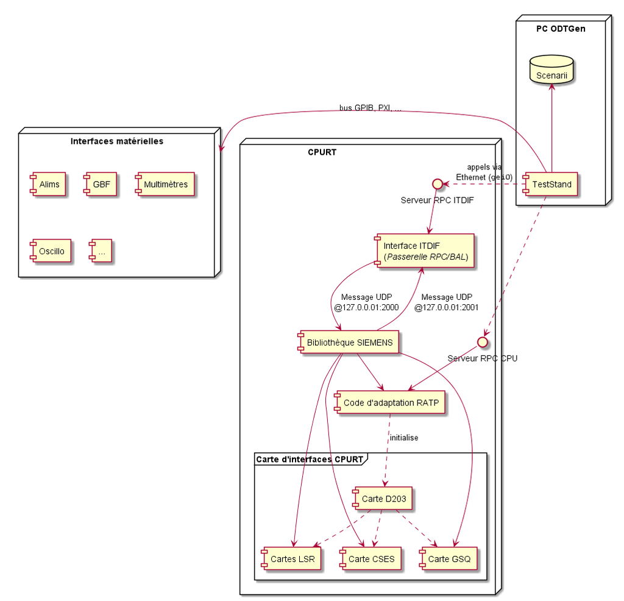

Figure 1 : Composants principaux du projet

Voici un diagramme de séquences entièrement rédigé en mode texe :

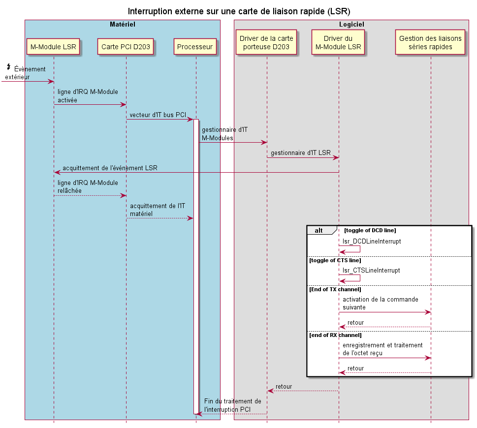

Figure 2 : Diagramme de séquence PlantUML

# 3 Titre de niveau 1

## 3.1 Titre de niveau 2

### 3.1.1 Titre de niveau 3

ceci est un paragraphe.

### 3.1.2 Titre de niveau 3

Et voila un exemple de liste non-numérotée :

- pomme
- poire
- carotte
- navet

Voici un exemple de liste numérotée :

1. Tintin
2. Milou
3. Haddock

Et un exemple de *todo list* (cases à cocher) :

- non coché
- coché

### 3.1.3 Titre de niveau 3

> Ceci est une citation : « C’est curieux chez les marins ce besoin de faire des phrases ! »

## 3.2 Autre titre de niveau 2

Ce fichier `.md` est encodé en UTF8, pour ne pas avoir de problème lors de l’utilisation de caractères accentués ou spéciaux.

Exemple de code source en C :

```c
#include "triangle.h"
#include <math.h>

//====================================================================
// Determination du type d'un triangle
//====================================================================
char* QualifierTriangle(unsigned int a, unsigned int b, unsigned int c)
{
    if( a+b<=c || b+c<=a || c+a<=b )
    {
        return "impossible";
    }
    else
    {
        unsigned int egalite=0;
        if (a==b) egalite++;
        if (a==c) egalite++;
        if (c==b) egalite++;

        if (egalite==0)      return "quelconque";
        else if (egalite==1) return "isocele";
        else                 return "equilateral";
    }
}
```

avec le logigramme associé, rédigé en mode texte, et traité par le logiciel PlantUML pour en générer une image :

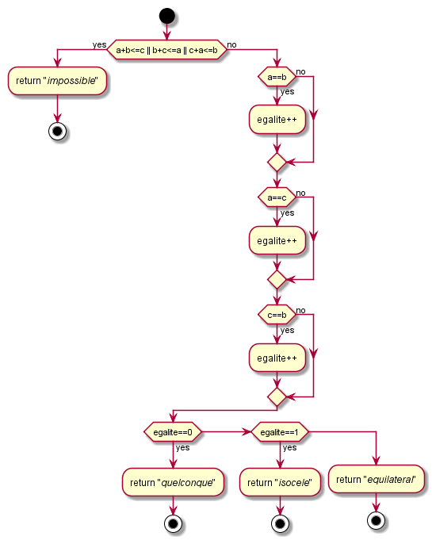

Figure 3 : Logigramme de qualification d’un triangle

ou bien en java

```java
public class HelloWorld {

    public static void main(String[] args) {
        System.out.println("Hello, World");
    }

}
```

ou bien en python (*on appréciera au passage la concision du language par rapport au java !*) :

```python
print "Hello World"
```

Exemple de diagrammes de temps généré à l’aide de PlantUML :

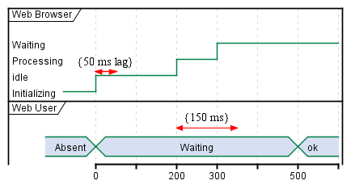

Figure 4 : Diagramme de temps : Affichage d’une page Web

Exemples de diagrammes de Gantt générés à l’aide de PlantUML :

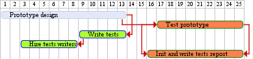

Figure 5 : Diagramme de Gantt

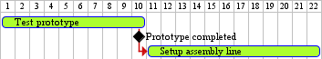

Figure 6 : Diagramme de Gantt

## 3.3 Notations mathématiques

Exemple de notation mathématique, en mettant le texte entre deux dollars :

- $1 + 1 = 2$
- $\sqrt{\frac{x^2}{3}}$
- $x_{1,2} = \frac{- b \pm \sqrt{\Delta}}{2a}$
- $\begin{bmatrix} a_1 & b_1 \\ a_2 & b_2 \end{bmatrix}$
- $\sum_{x=0}^n f(x)$

## 3.4 Diagrammes divers

Example usage:

[figure not shown]

This is an image, created by **PlantUML**.

### 3.4.1 Graphviz

To use Graphviz you only need to install Graphviz, as you can read on its [website](http://www.graphviz.org/). There are no other dependencies.

This filter assumes that the `dot` command is located in the path and therefore can be used from any location. Alternatively, you can set the environment variable `DOT` or use the pandoc’s meta variable `dotPath`.

Example usage from [the Graphviz gallery](https://graphviz.gitlab.io/_pages/Gallery/directed/fsm.html):

[figure not shown]

This is an image, created by **Graphviz**’s dot.